# To628Pj2

Shaochen Liu, Zewen Ai, Hanyi Shu, Jiajun Wang, Ruohan Wang

2019/11/30

# Introduction:

Our team gets the financial distress data from https://archive.ics.uci.edu/ml/datasets/Polish+companies+bankruptcy+data. The dataset is about the bankruptcy prediction of Polish companies. The data was collected from Emerging Markets Information Serviced. The bankrupt companies were analyzed in the period 2000-2012, while the still operating companies were evaluated from 2007 to 2013. In this project, we used the “5thYear” dataset, which contains financial rates from the 5th year of the forecasting period and corresponding class label that indicates bankruptcy status after one year. The data includes 5910 instances (financial statements), 410 represents bankrupted companies, 5500 firms that did not bankrupt in the forecasting period. The aim is to build models and conduct bankruptcy predication.

In our project, we used T-1 corporate financial data to predict the state of bankruptcy at T time. Our team has asked the following questions: 1. Which features will affect the probability of bankruptcy? 2.Among all factors, which factors are most indicative of bankruptcy? 3. What types of machine learning models perform best on this dataset?

# Part I: Clean Data

## Initial Data

We load the initial data and are trying to find out the null variable and fill in them through the mean method.

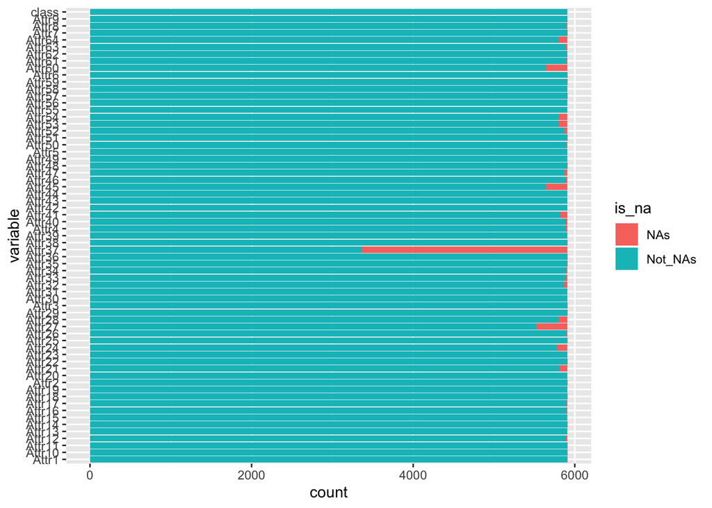

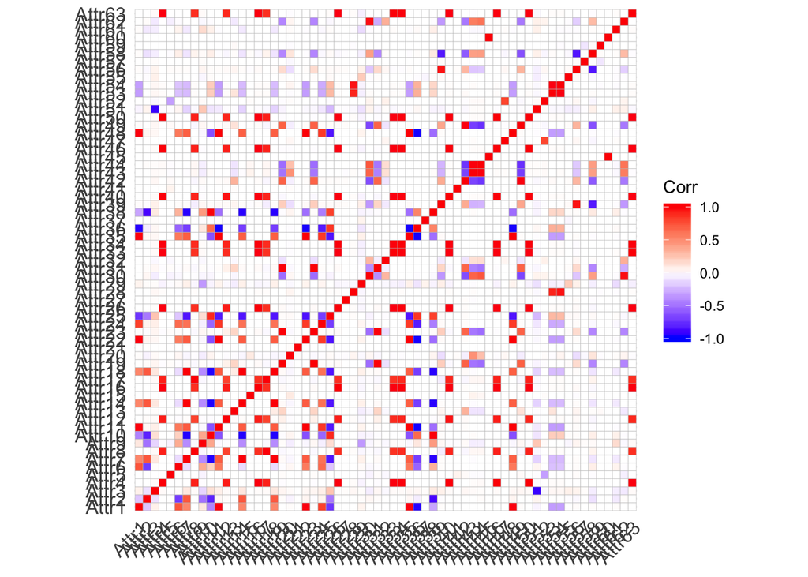

## Feature of Data

Based on the correlation table, we are going to delete the high correlate variables to remain the minimum amounts of variables with enough information based on the whole dataset.

```
## datadelete
##  Attr1 Attr10 Attr11 Attr12 Attr14 Attr16 Attr17 Attr18 Attr19  Attr2
##     11     12     13     11     13     11     11     13      6      6
## Attr22 Attr23 Attr24 Attr25 Attr26 Attr28  Attr3 Attr30 Attr31 Attr33
##     13      6     12     12     11      2      1      7      4     11
## Attr34 Attr35 Attr36 Attr38 Attr39  Attr4 Attr40 Attr42 Attr43 Attr44
##     11     13     13     11      2     11     11      8      5      7
## Attr45 Attr46 Attr47 Attr48 Attr49 Attr50 Attr51 Attr52 Attr53 Attr54
##      1     11      1     13      8     11      1      1      2      2
## Attr56 Attr58  Attr6 Attr60 Attr62 Attr63  Attr7  Attr8
##      2      4      8      1      3     11     13     11
```

We dropped the variables above always occurred, which are correlated to other variables. And we selected the variables which have no highly correlations.

### Bankruptcy with other variables

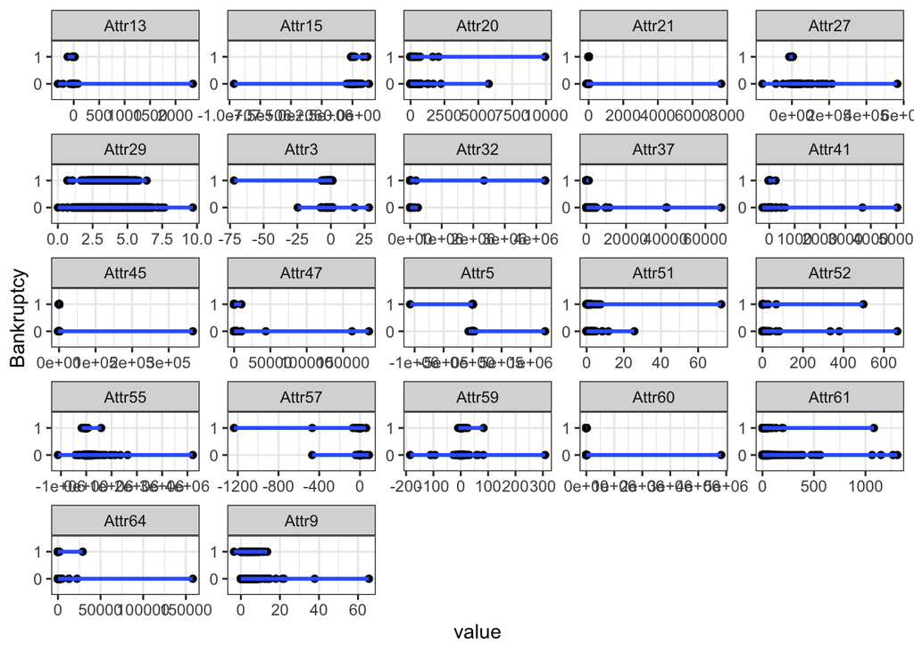

From the plots above, we can find the variables affect binary variable bankruptcy such as attr3, attr9, attr15, attr20, attr29, attr47, attr57. The detail information below.

3 = working capital / total assets

47 = (current assets - inventory - receivables) / short-term liabilities

57 = (current assets - inventory - short-term liabilities) / (sales - gross profit - depreciation)

9 = sales / total assets

15 = (total liabilities * 365) / (gross profit + depreciation)

20 = (inventory * 365) / sales

29 = logarithm of total assets

According to the financial knowledge, the varibales above do affect the operation of a company.

### Variables’s histogram

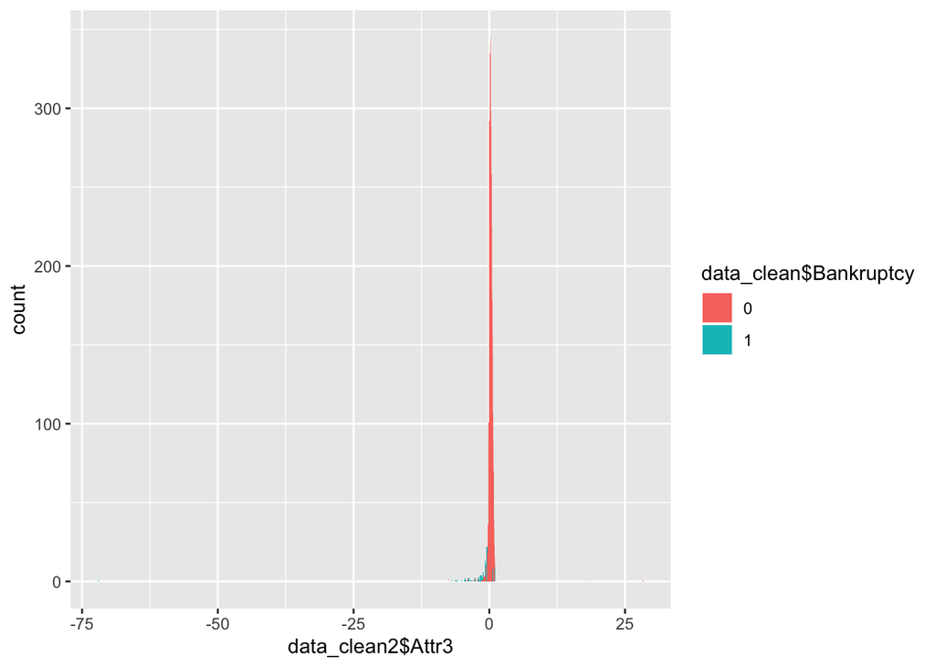

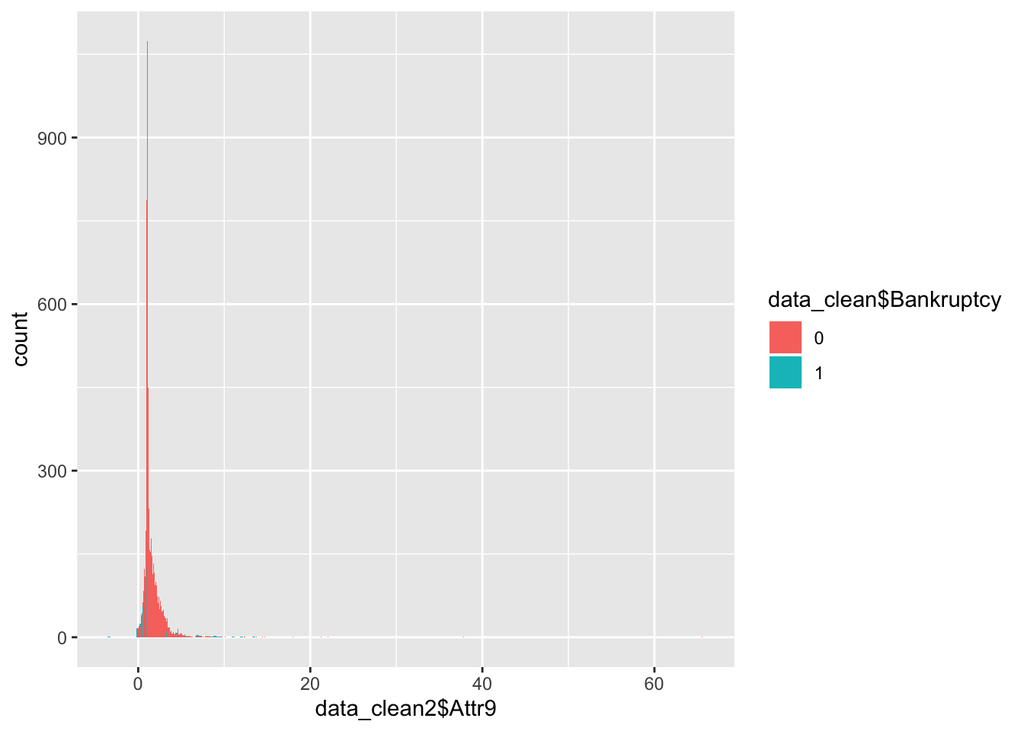

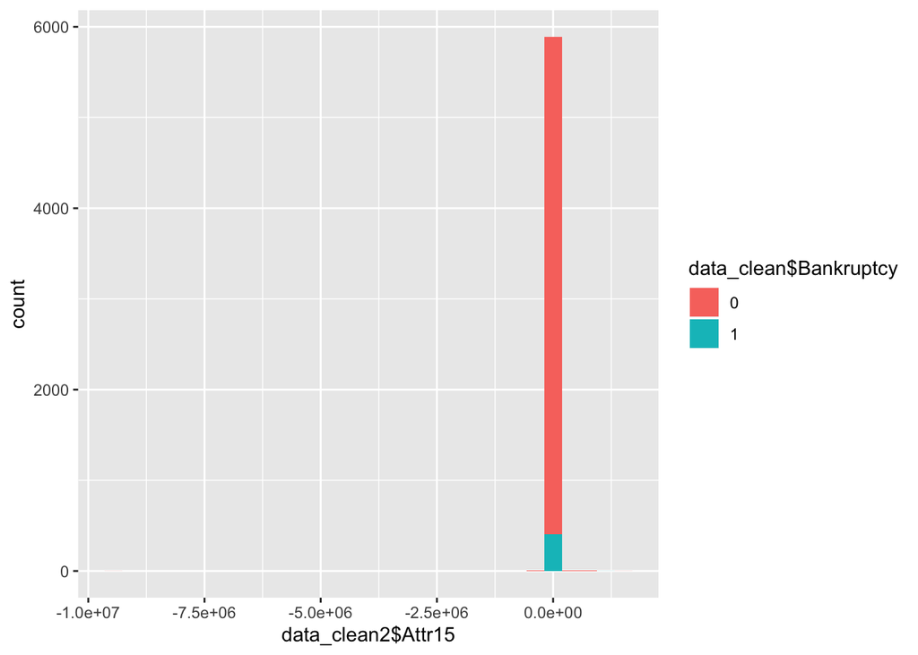

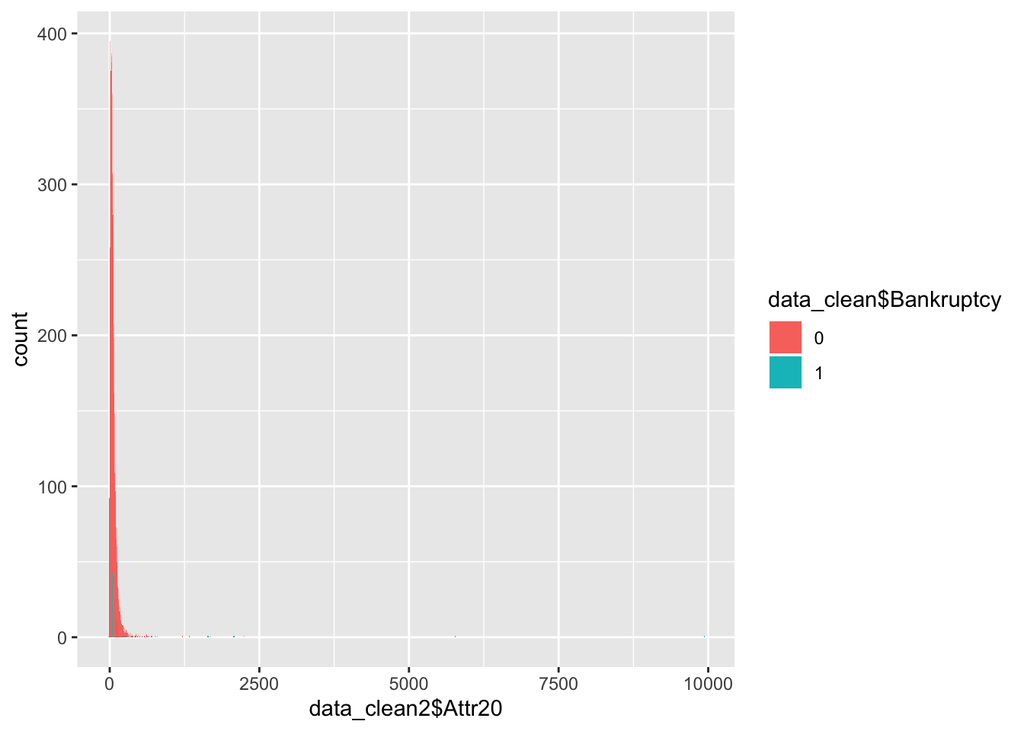

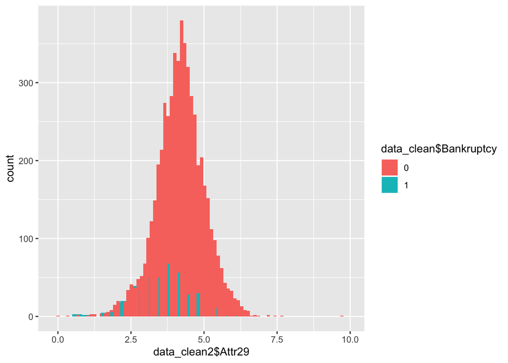

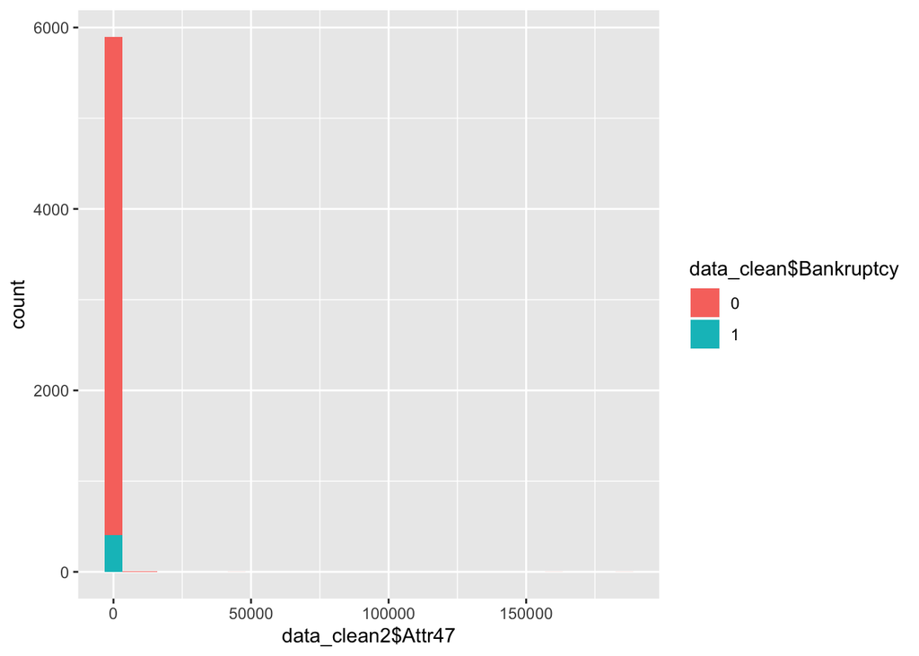

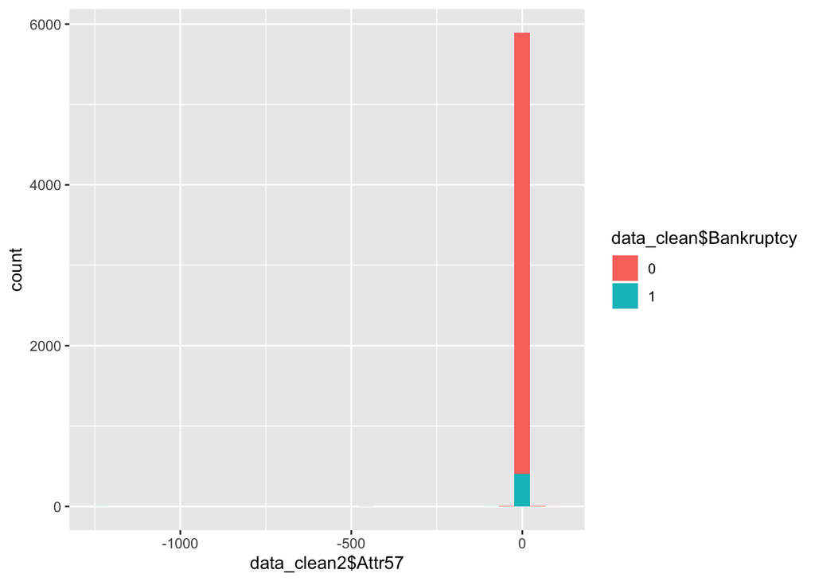

# Part II: Logistic model

Since the bankruptcy data is binary data, we just directly do the Logistic Regression Model and observe the effect of current financial performance on Bankruptcy.

Step1:

```
##
## Call:
## glm(formula = Bankruptcy ~ ., family = "binomial", data = train)
##
## Deviance Residuals:
##    Min      1Q  Median      3Q     Max
##  -8.49    0.00    0.00    0.00    8.49
##
## Coefficients: (1 not defined because of singularities)
##               Estimate Std. Error    z value Pr(>|z|)
## (Intercept)  3.743e+14  1.001e+07   37408984   <2e-16 ***
## Attr1        6.444e+14  2.186e+07   29483415   <2e-16 ***
## Attr2       -1.082e+15  1.815e+07  -59643428   <2e-16 ***
## Attr3       -3.207e+14  5.292e+06  -60596140   <2e-16 ***
## Attr4       -9.818e+13  9.583e+05 -102452510   <2e-16 ***
## Attr5        4.354e+10  7.265e+02   59926306   <2e-16 ***
## Attr6        3.967e+13  9.358e+05   42389136   <2e-16 ***
## Attr7        8.919e+19  1.932e+12   46162548   <2e-16 ***
## Attr8        7.555e+12  1.364e+06    5538125   <2e-16 ***
## Attr9       -1.071e+13  1.482e+06   -7224594   <2e-16 ***
## Attr10      -1.158e+15  1.918e+07  -60357251   <2e-16 ***
## Attr11      -1.425e+15  2.155e+07  -66134832   <2e-16 ***
## Attr12       4.464e+13  3.313e+05  134725675   <2e-16 ***
## Attr13       2.395e+16  1.809e+08  132367189   <2e-16 ***
## Attr14      -8.919e+19  1.932e+12  -46161832   <2e-16 ***
## Attr15      -1.288e+09  3.983e+01  -32344251   <2e-16 ***
## Attr16      -2.627e+14  3.838e+06  -68440880   <2e-16 ***
## Attr17      -1.336e+13  1.363e+06   -9800201   <2e-16 ***
## Attr18              NA         NA         NA       NA
## Attr19      -2.301e+16  1.844e+08 -124786141   <2e-16 ***
## Attr20      -7.798e+14  1.975e+08   -3948457   <2e-16 ***
## Attr21      -5.481e+11  8.769e+03  -62506401   <2e-16 ***
## Attr22      -8.444e+14  9.778e+06  -86359828   <2e-16 ***
## Attr23      -1.338e+15  3.515e+07  -38067966   <2e-16 ***
## Attr24      -4.418e+13  7.927e+05  -55729766   <2e-16 ***
## Attr25       1.764e+14  3.180e+06   55481901   <2e-16 ***
## Attr26       2.353e+14  3.925e+06   59953817   <2e-16 ***
## Attr27      -5.226e+08  9.666e+01   -5406738   <2e-16 ***
## Attr28      -4.670e+12  1.478e+05  -31599981   <2e-16 ***
## Attr29      -1.185e+14  1.626e+06  -72886483   <2e-16 ***
```

[output cut: 30 more lines]

```
## Attr60      -6.476e+09  1.887e+03   -3432967   <2e-16 ***
## Attr61       2.725e+11  2.667e+04   10217894   <2e-16 ***
## Attr62      -7.512e+10  3.039e+03  -24718956   <2e-16 ***
## Attr63      -3.265e+13  2.799e+05 -116643625   <2e-16 ***
## Attr64      -2.228e+08  3.984e+03     -55917   <2e-16 ***
## ---
## Signif. codes:  0 '***' 0.001 '**' 0.01 '*' 0.05 '.' 0.1 ' ' 1
##
## (Dispersion parameter for binomial family taken to be 1)
##
##     Null deviance:  2034.3  on 3999  degrees of freedom
## Residual deviance: 57093.1  on 3936  degrees of freedom
## AIC: 57221
##
## Number of Fisher Scoring iterations: 25
```

Step2: All variables are significant from the logistic model above, we doubt the high correlation of variables causes that. To select the variables, We dropped the variables which are correlated to more other variables. And we decided on the variables which have no highly correlations. [Based on the method we did in the feature of data.]

Step 3: Conduct the best logistic model for now.

```
##
## Call:
## glm(formula = Bankruptcy ~ Attr3 + Attr45 + Attr47 + Attr51 +
##     Attr52 + Attr60 + Attr64 + Attr61 + Attr55 + Attr57 + Attr59 +
##     Attr5 + Attr9 + Attr13 + Attr15 + Attr20 + Attr21 + Attr27 +
##     Attr29 + Attr32 + Attr37 + Attr41, family = "binomial", data = train)
##
## Deviance Residuals:
##     Min       1Q   Median       3Q      Max
## -4.5328  -0.3850  -0.3137  -0.2440   3.6753
##
## Coefficients:
##               Estimate Std. Error z value Pr(>|z|)
## (Intercept)  1.484e+00  4.656e-01   3.188 0.001433 **
## Attr3       -1.179e+00  3.116e-01  -3.782 0.000156 ***
## Attr45      -1.384e-03  2.320e-03  -0.596 0.550850
## Attr47      -3.597e-03  1.647e-03  -2.184 0.028985 *
## Attr51      -4.493e-01  3.335e-01  -1.347 0.177847
## Attr52      -1.114e-01  1.421e-01  -0.784 0.432894
## Attr60      -1.924e-04  2.394e-04  -0.804 0.421492
## Attr64      -1.563e-04  3.799e-04  -0.411 0.680736
## Attr61      -3.657e-04  1.116e-03  -0.328 0.743232
## Attr55      -3.515e-06  3.068e-06  -1.146 0.251936
## Attr57      -5.192e-02  2.454e-02  -2.116 0.034345 *
## Attr59       1.541e-02  2.939e-02   0.524 0.600091
## Attr5        2.183e-05  5.537e-05   0.394 0.693431
## Attr9       -1.694e-01  6.177e-02  -2.743 0.006089 **
## Attr13       3.300e-02  2.229e-02   1.480 0.138767
## Attr15      -1.036e-05  3.432e-06  -3.018 0.002544 **
## Attr20       3.377e-03  1.166e-03   2.897 0.003765 **
## Attr21      -2.832e-04  1.713e-03  -0.165 0.868635
## Attr27      -1.031e-05  1.633e-05  -0.631 0.528053
## Attr29      -8.540e-01  9.241e-02  -9.241  < 2e-16 ***
## Attr32       2.460e-04  1.733e-04   1.419 0.155765
## Attr37      -2.100e-04  5.261e-04  -0.399 0.689810
## Attr41      -7.066e-03  6.828e-03  -1.035 0.300739
## ---
## Signif. codes:  0 '***' 0.001 '**' 0.01 '*' 0.05 '.' 0.1 ' ' 1
##
## (Dispersion parameter for binomial family taken to be 1)
##
##     Null deviance: 2034.3  on 3999  degrees of freedom
## Residual deviance: 1781.6  on 3977  degrees of freedom
## AIC: 1827.6
##
## Number of Fisher Scoring iterations: 12
```

```
##
## Call:
## glm(formula = Bankruptcy ~ Attr3 + Attr47 + Attr51 + Attr57 +
##     Attr9 + Attr15 + Attr20 + Attr29, family = "binomial", data = train)
##
## Deviance Residuals:
##     Min       1Q   Median       3Q      Max
## -4.8045  -0.3800  -0.3135  -0.2520   3.3582
##
## Coefficients:
##               Estimate Std. Error z value Pr(>|z|)
## (Intercept)  1.322e+00  4.240e-01   3.117  0.00183 **
## Attr3       -1.228e+00  2.947e-01  -4.165 3.11e-05 ***
## Attr47      -2.787e-03  1.520e-03  -1.834  0.06672 .
## Attr51      -4.560e-01  3.176e-01  -1.436  0.15110
## Attr57      -5.518e-02  2.375e-02  -2.324  0.02013 *
## Attr9       -1.758e-01  5.773e-02  -3.046  0.00232 **
## Attr15      -1.007e-05  3.416e-06  -2.948  0.00320 **
## Attr20       2.969e-03  1.041e-03   2.852  0.00435 **
## Attr29      -8.282e-01  8.612e-02  -9.616  < 2e-16 ***
## ---
## Signif. codes:  0 '***' 0.001 '**' 0.01 '*' 0.05 '.' 0.1 ' ' 1
##
## (Dispersion parameter for binomial family taken to be 1)
##
##     Null deviance: 2034.3  on 3999  degrees of freedom
## Residual deviance: 1790.9  on 3991  degrees of freedom
## AIC: 1808.9
##
## Number of Fisher Scoring iterations: 10
```

# Part III: Model Selection

Based on the historical financial data of a sample of companies, we applied logistic regression, KKN, random forest, and other models to predict the probability of bankruptcy.

## Model 1: Logistic

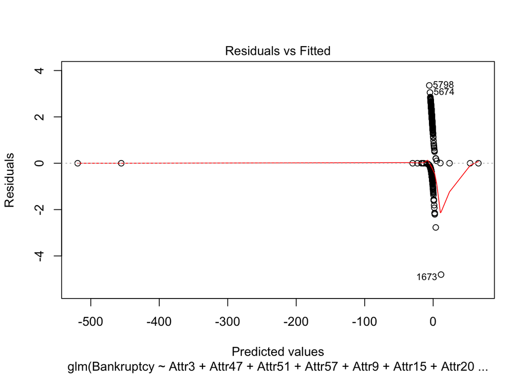

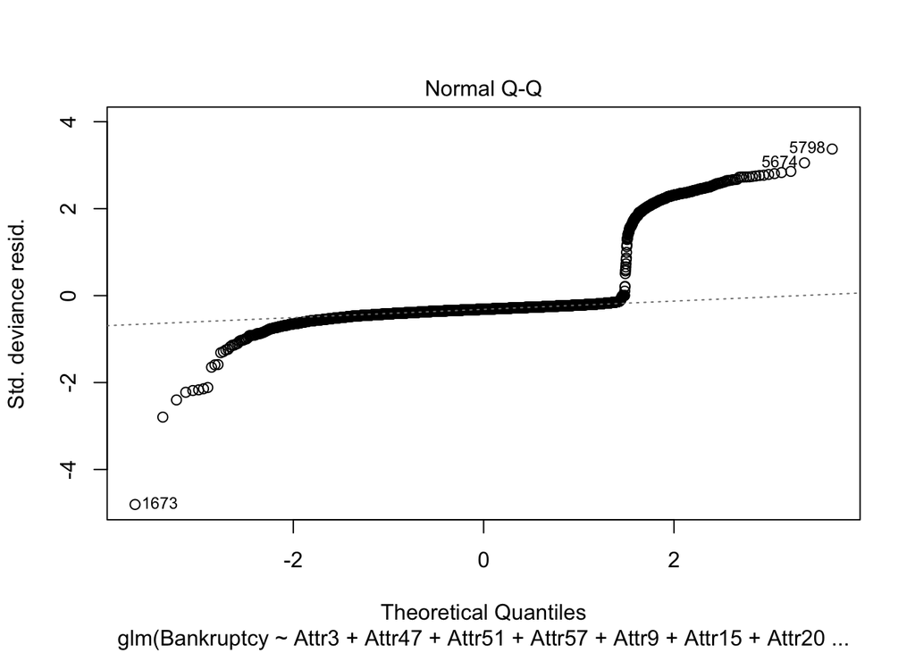

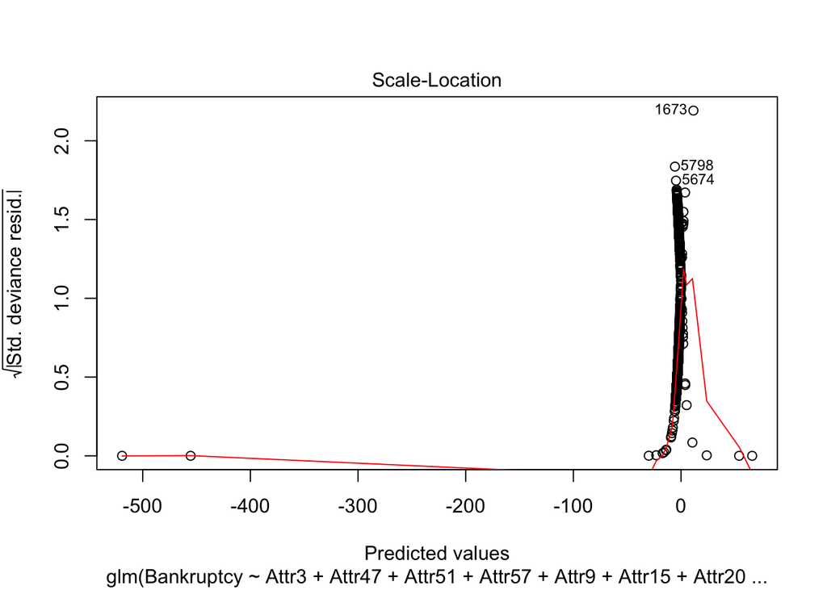

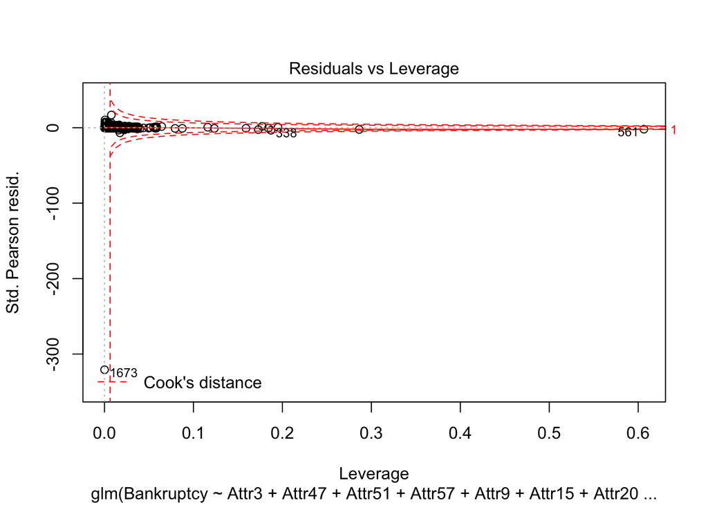

```
##
## Call:
## glm(formula = Bankruptcy ~ Attr3 + Attr47 + Attr51 + Attr57 +
##     Attr9 + Attr15 + Attr20 + Attr29, family = "binomial", data = train)
##
## Deviance Residuals:
##     Min       1Q   Median       3Q      Max
## -4.8045  -0.3800  -0.3135  -0.2520   3.3582
##
## Coefficients:
##               Estimate Std. Error z value Pr(>|z|)
## (Intercept)  1.322e+00  4.240e-01   3.117  0.00183 **
## Attr3       -1.228e+00  2.947e-01  -4.165 3.11e-05 ***
## Attr47      -2.787e-03  1.520e-03  -1.834  0.06672 .
## Attr51      -4.560e-01  3.176e-01  -1.436  0.15110
## Attr57      -5.518e-02  2.375e-02  -2.324  0.02013 *
## Attr9       -1.758e-01  5.773e-02  -3.046  0.00232 **
## Attr15      -1.007e-05  3.416e-06  -2.948  0.00320 **
## Attr20       2.969e-03  1.041e-03   2.852  0.00435 **
## Attr29      -8.282e-01  8.612e-02  -9.616  < 2e-16 ***
## ---
## Signif. codes:  0 '***' 0.001 '**' 0.01 '*' 0.05 '.' 0.1 ' ' 1
##
## (Dispersion parameter for binomial family taken to be 1)
##
##     Null deviance: 2034.3  on 3999  degrees of freedom
## Residual deviance: 1790.9  on 3991  degrees of freedom
## AIC: 1808.9
##
## Number of Fisher Scoring iterations: 10
```

```
##
## bankruptcy.pred    0    1
##               0 1773  122
##               1    8    7
```

```
## agreement_log
## FALSE  TRUE
##   130  1780
```

```
## agreement_log
##      FALSE       TRUE
## 0.06806283 0.93193717
```

The accuracy for logistic model: 0.9319372

### ROC curve

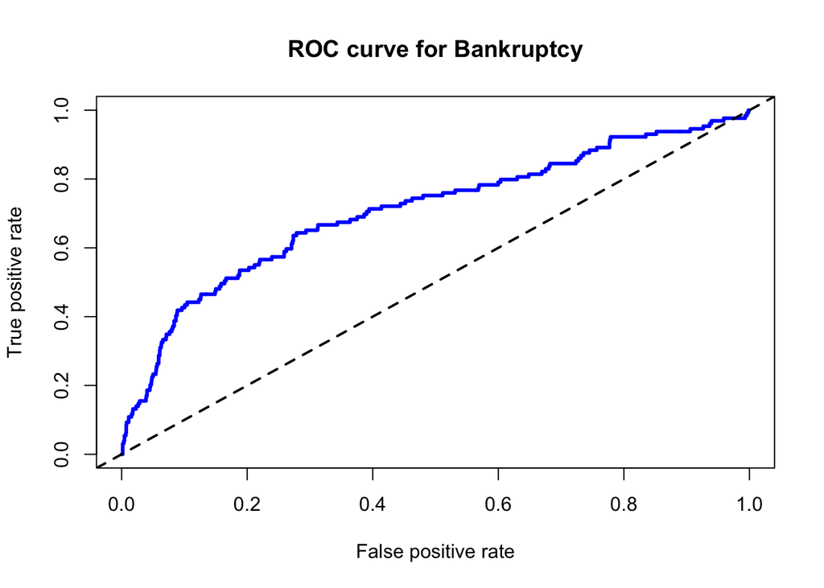

## Model 2: KNN

```
## [1] 1
## [1] 0.8968586
## [1] 3
## [1] 0.9183246
## [1] 5
## [1] 0.9277487
## [1] 7
## [1] 0.9324607
## [1] 9
## [1] 0.9340314
## [1] 11
## [1] 0.9335079
## [1] 13
## [1] 0.9324607
## [1] 15
## [1] 0.9314136
```

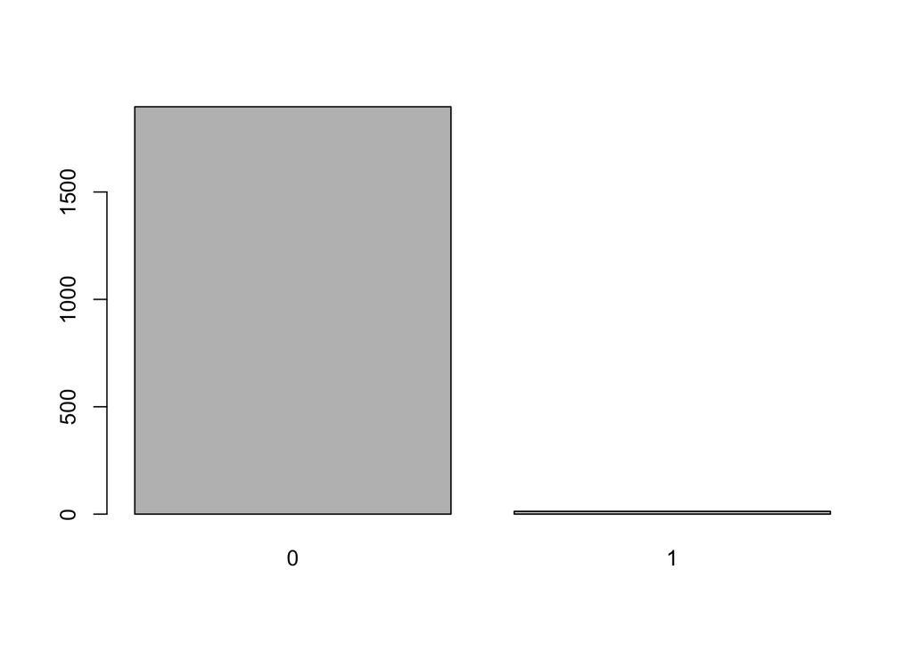

```
##    0    1
## 1897   13
```

```
##
##
##    Cell Contents
## |-------------------------|
## |                       N |
## |           N / Row Total |
## |           N / Col Total |
## |         N / Table Total |
## |-------------------------|
##
##
## Total Observations in Table:  1910
##
##
##                 | knn_best_pred
## knn_test_labels |         0 |         1 | Row Total |
## ----------------|-----------|-----------|-----------|
##               0 |      1776 |         5 |      1781 |
##                 |     0.997 |     0.003 |     0.932 |
##                 |     0.936 |     0.385 |           |
##                 |     0.930 |     0.003 |           |
## ----------------|-----------|-----------|-----------|
##               1 |       121 |         8 |       129 |
##                 |     0.938 |     0.062 |     0.068 |
##                 |     0.064 |     0.615 |           |
##                 |     0.063 |     0.004 |           |
## ----------------|-----------|-----------|-----------|
##    Column Total |      1897 |        13 |      1910 |
##                 |     0.993 |     0.007 |           |
## ----------------|-----------|-----------|-----------|
##
##
```

```
##              knn_test_labels
## knn_best_pred    0    1
##             0 1776  121
##             1    5    8
```

```
## agreement_knn
## FALSE  TRUE
##   126  1784
```

```
## agreement_knn
##      FALSE       TRUE
## 0.06596859 0.93403141
```

The Accuracy for knn model is: 0.9340314

## Model 3: Decision Tree

[figure not shown]

```
##
## b_modeldt_pred    0    1
##              0 1767   55
##              1   14   74
```

```
## agreement_dt
## FALSE  TRUE
##    69  1841
```

```
## agreement_dt
##      FALSE       TRUE
## 0.03612565 0.96387435
```

The Accurancy for decision tree is: 0.9638743

Then we used the ipred bagged decision tree

```
##
## b_pred    0    1
##      0 5500    6
##      1    0  404
```

```
## Bagged CART
##
## 5910 samples
##   64 predictor
##    2 classes: '0', '1'
##
## No pre-processing
## Resampling: Cross-Validated (10 fold)
## Summary of sample sizes: 5319, 5319, 5319, 5319, 5319, 5319, ...
## Resampling results:
##
##   Accuracy   Kappa
##   0.9637902  0.6757133
```

The accurate rate of ipred bagged trees model gets the rate of 0.9637902 with Kappa rate of 0.6757133.

## Model 4: Random Forest

```
##
## Call:
##  randomForest(formula = Bankruptcy ~ ., data = data_rand, mtry = 8,      ntree = 2000)
##                Type of random forest: classification
##                      Number of trees: 2000
## No. of variables tried at each split: 8
##
##         OOB estimate of  error rate: 4.43%
## Confusion matrix:
##      0   1 class.error
## 0 5460  40 0.007272727
## 1  222 188 0.541463415
```

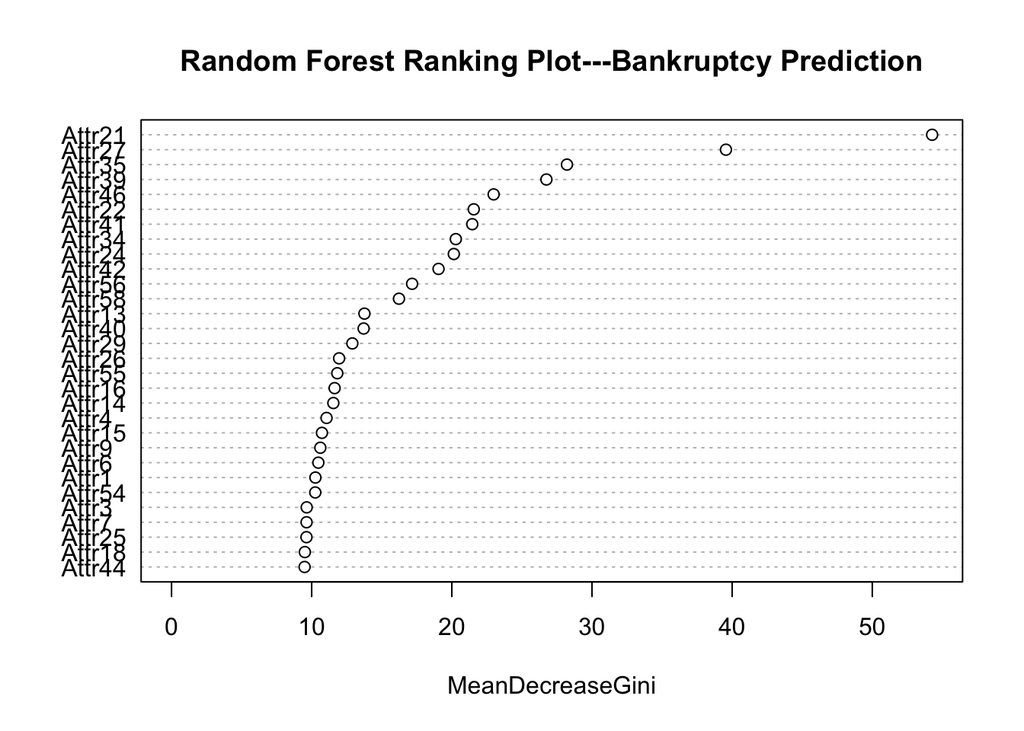

Accrancy: for the random forest model, the acurrancy is 95.57%

## Model 5: Neural Network

```
##
##
##    Cell Contents
## |-------------------------|
## |                       N |
## |         N / Table Total |
## |-------------------------|
##
##
## Total Observations in Table:  1910
##
##
##                    | predicted_results1
## nn_test$Bankruptcy |         1 | Row Total |
## -------------------|-----------|-----------|
##                  0 |      1781 |      1781 |
##                    |     0.932 |           |
## -------------------|-----------|-----------|
##                  1 |       129 |       129 |
##                    |     0.068 |           |
## -------------------|-----------|-----------|
##       Column Total |      1910 |      1910 |
## -------------------|-----------|-----------|
##
##
```

```
##
## predicted_results1    0    1
##                  1 1781  129
```

```
## agreement_nn
## FALSE  TRUE
##  1781   129
```

```
## agreement_nn
##      FALSE       TRUE
## 0.93246073 0.06753927
```

## Model 6: SVM Model

```
##
## b_predictions    0    1
##             0 1770  125
##             1   11    4
```

```
## agreement_svm
## FALSE  TRUE
##   136  1774
```

```
## agreement_svm
##      FALSE       TRUE
## 0.07120419 0.92879581
```

Accrancy: for the SVM model, the acurrancy is: 0.9287958

# Part IV: Best model Analysis

Answer the questions we mentioned before

[output not shown]

[figure not shown]

The problems mentioned at the beginning of the report showed below.

Q2.Among all factors, which factors are most indicative of bankruptcy? When estimating the healthy states of companies, we could emphasize Working capital, Operation Capability, and asset-liability position and Solvency indicators, These financial performances could help us to conclude whether it would be bankruptcy next year.

Q3.What types of machine learning models perform best on this dataset? After applying the logistic model and various models, We select our best final model–Decision Tree. Its predicted accuracy is 96.39%.

Q4.Who can benefit from this model? 1. Bank/lender- This model can be used to decide if we should give those companies loans depending on the key factors. By predicting the bankruptcy of a company, lenders are able to control cash flow risk and protect themselves from bad debt scenarios in order to achieve stability. 2. Companies- Since we take into consideration the lag effect of all variables, it is possible for companies to leverage the key current operation or financial factors to detect the company health state in advance. 3. Regulating agency/ Rating agency- Set criterias for company financial health.

Q5: How to use this model? This model’s key predictor variables are from the companies’ financial reports. And all of these factors are very common in internal or external financial audit and evaluation. Thus, no matter for bank, companies or regulation agencies, they can utilize our model easily–just find these easily accessible variables in the financial reports and apply our model. Then they can predict the probability of bankruptcy.

# Appendix

```
## Appendix

Data Description

Attr1   net profit / total assets
Attr2   total liabilities / total assets
Attr3   working capital / total assets
Attr4   current assets / short-term liabilities
Attr5   [(cash + short-term securities + receivables - short-term liabilities) / (operating expenses - depreciation)] * 365
Attr6   retained earnings / total assets
Attr7   EBIT / total assets
Attr8   book value of equity / total liabilities
Attr9   sales / total assets
Attr10  equity / total assets
Attr11  (gross profit + extraordinary items + financial expenses) / total assets
Attr12  gross profit / short-term liabilities
Attr13  (gross profit + depreciation) / sales
Attr14  (gross profit + interest) / total assets
Attr15  (total liabilities * 365) / (gross profit + depreciation)
Attr16  (gross profit + depreciation) / total liabilities
Attr17  total assets / total liabilities
Attr18  gross profit / total assets
Attr19  gross profit / sales
Attr20  (inventory * 365) / sales
Attr21  sales (n) / sales (n-1)
Attr22  profit on operating activities / total assets
Attr23  net profit / sales
Attr24  gross profit (in 3 years) / total assets
Attr25  (equity - share capital) / total assets
Attr26  (net profit + depreciation) / total liabilities
Attr27  profit on operating activities / financial expenses
Attr28  working capital / fixed assets
Attr29  logarithm of total assets
Attr30  (total liabilities - cash) / sales
Attr31  (gross profit + interest) / sales
Attr32  (current liabilities * 365) / cost of products sold
Attr33  operating expenses / short-term liabilities
Attr34  operating expenses / total liabilities
Attr35  profit on sales / total assets
Attr36  total sales / total assets
```

[output cut: 13 more lines]

```
Attr50  current assets / total liabilities
Attr51  short-term liabilities / total assets
Attr52  (short-term liabilities * 365) / cost of products sold)
Attr53  equity / fixed assets
Attr54  constant capital / fixed assets
Attr55  working capital
Attr56  (sales - cost of products sold) / sales
Attr57  (current assets - inventory - short-term liabilities) / (sales - gross profit - depreciation)
Attr58  total costs /total sales
Attr59  long-term liabilities / equity
Attr60  sales / inventory
Attr61  sales / receivables
Attr62  (short-term liabilities *365) / sales
Attr63  sales / short-term liabilities
Attr64  sales / fixed assets
```